# CS5801 Coursework Supporting analysis Template Proforma

2433795

06 fevereiro, 2025

# 0. Instructions

*This markdown is to be submitted in support of the one that will be used for marking. This may be used to confirm that the results presented in the submission are justified and that the claims made are backed up*

*1. Keep the section headings.*

*2. Add as many chunks of R code as required and make sure there are some explanations*

*3. Write your report using RMarkdown. For guidance see a [helpful blog](https://www.dataquest.io/blog/r-markdown-guide-cheatsheet/#tve-jump-17333da0719) or use the R Markdown cheatsheet which can be accessed from within RStudio by selecting `Help > Cheatsheets > R Markdown Cheat Sheet`.*

*4. This markdown document needs to run end to end without errors*

```r
# Add code here to load all the required libraries with `library()`.
# Do not include any `install.package()` for any required packages in this rmd file.
library(Hmisc)
```

```r
library(ggplot2)
```

# 1. Organise and clean the data

## 1.1 Subset the data into the specific dataset allocated

*A description of the data set provided, its contents and which subset you should select is documented in the assessment brief at CS5801-Assessment Brief Template 2024-25.pdf*

*Use R code to correctly select the subset of data allocated.*

```r
# Only change the value for SID
# Assign your student id into the variable SID, for example:
SID <- 2433795                 # This is an example, replace 2101234 with your actual ID
SIDoffset <- (SID %% 50) + 1    # Your SID mod 50 + 1

load("student_data.Rda")
# Now subset the student data set
# Pick every 50th observation starting from your offset
# Put into your data frame named mydf (you can rename it)
mydf <- student_data_analysis[seq(from=SIDoffset,to=nrow(student_data_analysis),by=50),]
```

```r
mydf
```

|  | student_id | entry_exam_mark | sat_score | percentage_absence | free_school_meals | grade_point_average | completed.extended.project | month_of_birth | commute_method |
| --- | --- | --- | --- | --- | --- | --- | --- | --- | --- |
| 46 | 46 | 59.77 | 686 | 10.51 | Yes | 2.03 | No | July | Bus |
| 96 | 96 | 55.59 | 888 | 5.69 | Yes | 2.34 | No | April | Bus |
| 146 | 146 | 63.48 | 1058 | 17.31 | No | 2.44 | No | October | Other |
| 196 | 196 | 85.74 | 1469 | 14.77 | No | 3.48 | Yes | November | Walking |
| 246 | 246 | 74.73 | 1227 | 0.00 | No | 3.63 | Yes | January | Car |
| 296 | 296 | 80.98 | 1053 | 10.64 | No | 2.55 | No | March | Bus |
| 346 | 346 | 57.64 | 700 | 15.07 | Yes | 1.58 | No | April | Bus |
| 396 | 396 | 83.29 | 1056 | 0.00 | No | 3.32 | Yes | April | Walking |
| 446 | 446 | 60.46 | 1128 | 14.37 | No | 2.56 | Yes | August | Bus |
| 496 | 496 | 71.21 | 656 | 3.46 | Yes | 1.46 | No | January | Car |

[output cut: 390 more lines]

## 1.2 Data quality plan

> The first for my quality plan is to understand the dataset that I’ll be working on. For that, I will gather the information from the metadata to understand each column and also the range of values that are expected. After that I can start checking possible errors in the dataset, checking the following aspects:
1. Null values
2. Duplicated rows
3. Duplicated values in columns supposed to have unique values
4. Data-types
5. If values meet the expected range (min - max)
6. Outliers
7. Typos (in categorical columns)
8. Any other especific rule

> To make my work easier, I’ll use the {validate} package, defining a rule for each variable and automatically making the assessment of quality for each column. (this package was used in the Week 5 - Modern Data Lab)

> After identifying possible problems I’ll analyze how to better address each one of the issues found in order to assure the quality of our dataset. The main cleaning options are:
- Ignore: when the issue has no significant impact on the dataset quality and cannot be addressed effectively using other data cleaning methods.
- Correct: editing values, replacing or deleting.
- Impute: replace issues with other reasonable values through mean, median, mode, regression methods and other more complex techniques.

*Use this section to add any code and explanations related to your data quality plan and execution*

## 1.3 Data quality analysis findings

### 1.3.1.1 Summary & {Validate Package}

```r
mydf
```

|  | student_id | entry_exam_mark | sat_score | percentage_absence | free_school_meals | grade_point_average | completed.extended.project | month_of_birth | commute_method |
| --- | --- | --- | --- | --- | --- | --- | --- | --- | --- |
| 46 | 46 | 59.77 | 686 | 10.51 | Yes | 2.03 | No | July | Bus |
| 96 | 96 | 55.59 | 888 | 5.69 | Yes | 2.34 | No | April | Bus |
| 146 | 146 | 63.48 | 1058 | 17.31 | No | 2.44 | No | October | Other |
| 196 | 196 | 85.74 | 1469 | 14.77 | No | 3.48 | Yes | November | Walking |
| 246 | 246 | 74.73 | 1227 | 0.00 | No | 3.63 | Yes | January | Car |
| 296 | 296 | 80.98 | 1053 | 10.64 | No | 2.55 | No | March | Bus |
| 346 | 346 | 57.64 | 700 | 15.07 | Yes | 1.58 | No | April | Bus |
| 396 | 396 | 83.29 | 1056 | 0.00 | No | 3.32 | Yes | April | Walking |
| 446 | 446 | 60.46 | 1128 | 14.37 | No | 2.56 | Yes | August | Bus |
| 496 | 496 | 71.21 | 656 | 3.46 | Yes | 1.46 | No | January | Car |

[output cut: 390 more lines]

```r
summary(mydf)
```

```
##    student_id    entry_exam_mark    sat_score      percentage_absence
##  Min.   :   46   Min.   :-73.00   Min.   : 363.0   Min.   :  0.000
##  1st Qu.: 5034   1st Qu.: 57.99   1st Qu.: 843.0   1st Qu.:  4.128
##  Median :10021   Median : 67.96   Median : 988.0   Median : 10.865
##  Mean   :10021   Mean   : 66.53   Mean   : 984.5   Mean   : 12.201
##  3rd Qu.:15008   3rd Qu.: 77.48   3rd Qu.:1129.2   3rd Qu.: 17.633
##  Max.   :19996   Max.   :100.00   Max.   :1600.0   Max.   :121.000
##  free_school_meals  grade_point_average completed.extended.project
##  Length:400         Min.   :0.840       Length:400
##  Class :character   1st Qu.:2.098       Class :character
##  Mode  :character   Median :2.425       Mode  :character
##                     Mean   :2.441
##                     3rd Qu.:2.763
##                     Max.   :3.760
##  month_of_birth     commute_method
##  Length:400         Length:400
##  Class :character   Class :character
##  Mode  :character   Mode  :character
##
##
##
```

> From the summary above is possible to get a simple overview of the columns of the dataset, and its values. Its also possible to notice a few seemingly incorrect values which will be further investigated. The cleaning strategy for each column will be explained in the next section (1.4)
1. student_id:

> In spite of some values with a low number of digits, after taking a look at the whole dataset, it appears to be normal to have a variation in number of digits.
2. entry_exam_mark:

> For this column values should vary from 0 to 100, nevertheless the min value is -73, which could be an error and the method to fix it will depend on the volume of negative values present in this column.
3. sat_score:

> First of all, we need to understand what sat_score means and the values we could expect to see in this column.

> Based on the metadata, SAT Scores varies from 0 to 1600.

> No errors detected.
4. percentage_absence

> As a percentage, values should vary from 0 to 100 but there is a max value of 121 on the column.
5. free_school_meals

> As a categoric column, the best way to check is from a table:

```r
table(mydf$free_school_meals)
```

```
##
##  No Yes
## 200 200
```

> Apparently there are no errors.
6. grade_point_average

> Also known as GPA, the grading point average should varies from 0 to 4, so no errors or outliers detected from looking at the summary.
7. completed.extended.project

```r
table(mydf$completed.extended.project)
```

```
##
##  No Yes
## 141 259
```

> Apparently there are no errors in this column.
8. month_of_birth

```r
table(mydf$month_of_birth)
```

```
##
##     April    August  December  February   January      July      June     March
##        40        32        30        35        36        31        35        27
##       May  November   October September
##        34        33        33        34
```

> Apparently there are no errors in this column.
9. Commute Method

```r
table(mydf$commute_method)
```

```
##
## Bicicle Bicycle     Bus     car     Car   Other Walking
##       2      47     130       2     105      31      83
```

> Looking at this column there are a few typos which could interfere my future analysis, as, for example, ‘car’ and ‘Car’ are considered two separate values.

#### 1.3.1.2 Validate Package

```r
# install.package("validate")
library(validate)
mydf.rules <- validator(okEntryMark = entry_exam_mark >= 0 & entry_exam_mark <= 100,
                             okSAT = sat_score >= 0 & sat_score <= 1600,
                             okPercAbs = percentage_absence >= 0 & percentage_absence <= 100,
                             okFreeMeals = is.element(free_school_meals,c("Yes","No")),
                             okGPA = grade_point_average >= 0,
                             okExProj = is.element(completed.extended.project,c("Yes","No")),
                             okCommute = is.element(commute_method,c("Bicycle", "Bus", "Car", "Walking", "Other")))
```

```r
# Getting the summary of the quality check
qual.check <- confront(mydf,mydf.rules)
summary(qual.check)
```

| name | items | passes | fails | nNA | error | warning | expression |
| --- | --- | --- | --- | --- | --- | --- | --- |
| okEntryMark | 400 | 396 | 4 | 0 | FALSE | FALSE | entry_exam_mark - 0 >= -1e-08 & entry_exam_mark - 100 <= 1e-08 |
| okSAT | 400 | 400 | 0 | 0 | FALSE | FALSE | sat_score - 0 >= -1e-08 & sat_score - 1600 <= 1e-08 |
| okPercAbs | 400 | 398 | 2 | 0 | FALSE | FALSE | percentage_absence - 0 >= -1e-08 & percentage_absence - 100 <= 1e-08 |
| okFreeMeals | 400 | 400 | 0 | 0 | FALSE | FALSE | is.element(free_school_meals, c("Yes", "No")) |
| okGPA | 400 | 400 | 0 | 0 | FALSE | FALSE | grade_point_average - 0 >= -1e-08 |
| okExProj | 400 | 400 | 0 | 0 | FALSE | FALSE | is.element(completed.extended.project, c("Yes", "No")) |
| okCommute | 400 | 396 | 4 | 0 | FALSE | FALSE | is.element(commute_method, c("Bicycle", "Bus", "Car", "Walking", "Other")) |

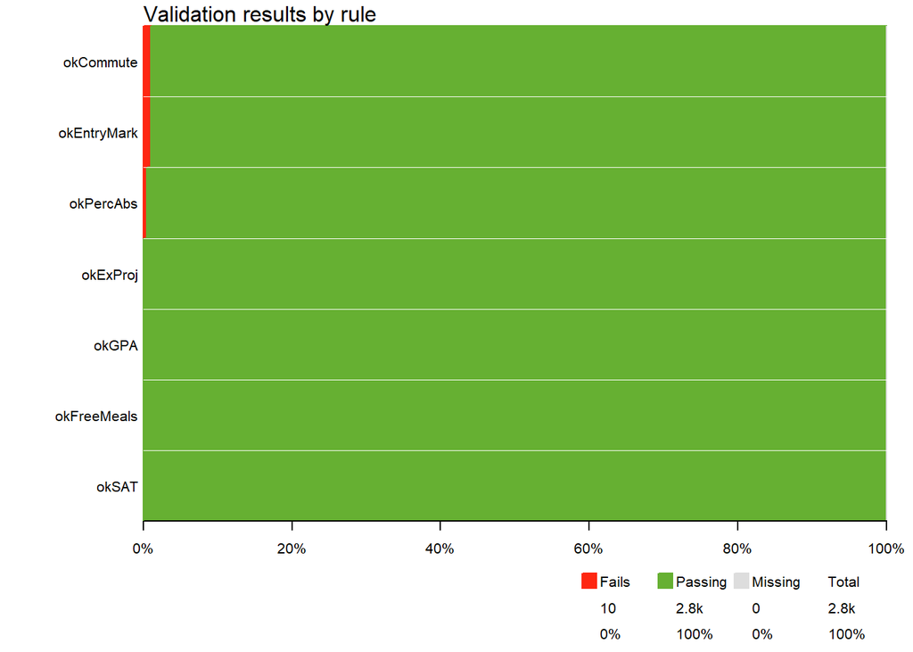

```r
# Plot the result of the rules we set using validate package
plot(qual.check, xlab = "")
```

### 1.3.2 Checking Duplicates

```r
# Check for duplicate rows in mydf
duplicate_rows <- mydf[duplicated(mydf), ]

duplicate_rows
```

| student_id | entry_exam_mark | sat_score | percentage_absence | free_school_meals | grade_point_average | completed.extended.project | month_of_birth | commute_method |
| --- | --- | --- | --- | --- | --- | --- | --- | --- |

> No duplicate rows found

```r
# Check duplicate values in unique valued column
duplicate_ids <- mydf$student_id[duplicated(mydf$student_id)]

duplicate_ids
```

```
## integer(0)
```

> No duplicate student_id values found

### 1.3.3 Checking Missing Values

```r
# Check for missing values in each column of mydf
missing_values <- colSums(is.na(mydf))

missing_values
```

```
##                 student_id            entry_exam_mark
##                          0                          0
##                  sat_score         percentage_absence
##                          0                          0
##          free_school_meals        grade_point_average
##                          0                          0
## completed.extended.project             month_of_birth
##                          0                          0
##             commute_method
##                          0
```

> No missing values found

### 1.3.4 Checking Data Types

```r
str(mydf)
```

```
## 'data.frame':    400 obs. of  9 variables:
##  $ student_id                : int  46 96 146 196 246 296 346 396 446 496 ...
##  $ entry_exam_mark           : num  59.8 55.6 63.5 85.7 74.7 ...
##  $ sat_score                 : num  686 888 1058 1469 1227 ...
##  $ percentage_absence        : num  10.51 5.69 17.31 14.77 0 ...
##  $ free_school_meals         : chr  "Yes" "Yes" "No" "No" ...
##  $ grade_point_average       : num  2.03 2.34 2.44 3.48 3.63 2.55 1.58 3.32 2.56 1.46 ...
##  $ completed.extended.project: chr  "No" "No" "No" "Yes" ...
##  $ month_of_birth            : chr  "July" "April" "October" "November" ...
##  $ commute_method            : chr  "Bus" "Bus" "Other" "Walking" ...
```

> Numerical and Integer columns have the correct data-type. Categorical column need to be converted into factors.

### 1.3.5 Checking the arrangement of values using boxplots

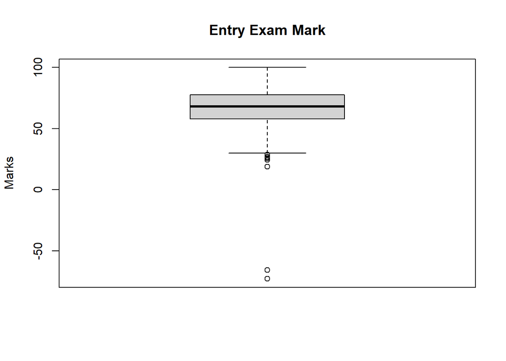

```r
# Boxplot for 'entry_exam_mark'
boxplot(mydf$entry_exam_mark, main = "Entry Exam Mark", ylab = "Marks")
```

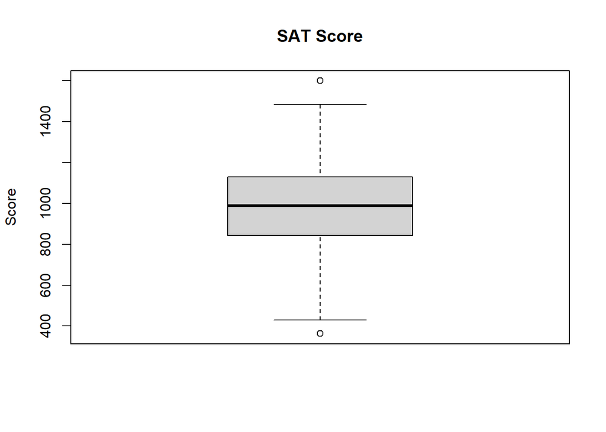

```r
# Boxplot for 'sat_score'
boxplot(mydf$sat_score, main = "SAT Score", ylab = "Score")
```

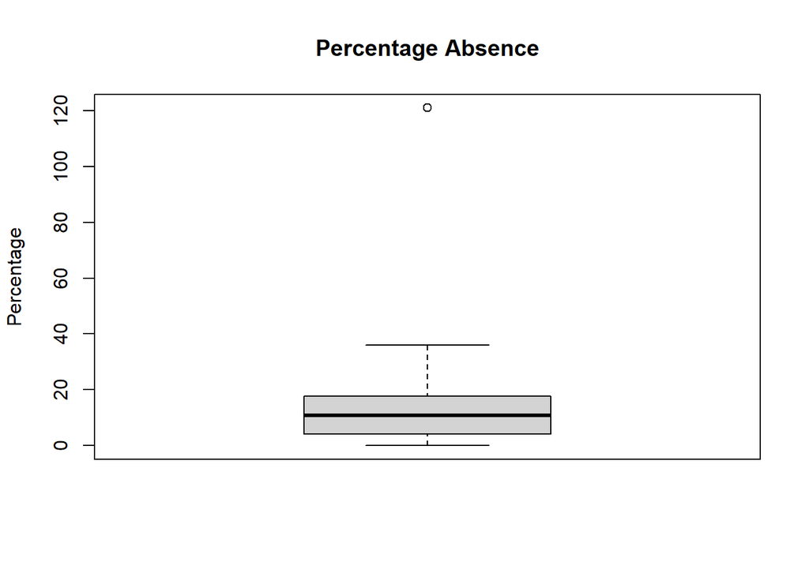

```r
# Boxplot for 'percentage_absence'
boxplot(mydf$percentage_absence, main = "Percentage Absence", ylab = "Percentage")
```

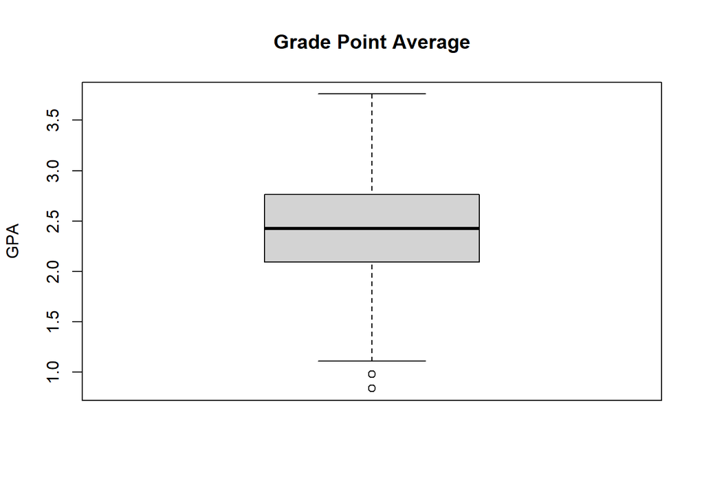

```r
# Boxplot for 'grade_point_average'
boxplot(mydf$grade_point_average, main = "Grade Point Average", ylab = "GPA")
```

*Use this section to include any relevant code and explanations related to your findings*

## 1.4 Data cleaning

### 1.4.1 - entry_mark_exam

> For this column, negative marks are not expected, however, they are present.

> It’s also important to check the volume of negative values present.

```r
negative_marks <- mydf[mydf$entry_exam_mark < 0, ]
negative_marks
```

|  | student_id | entry_exam_mark | sat_score | percentage_absence | free_school_meals | grade_point_average | completed.extended.project | month_of_birth | commute_method |
| --- | --- | --- | --- | --- | --- | --- | --- | --- | --- |
| 6046 | 6046 | -66 | 939 | 20.02 | Yes | 2.27 | No | September | Bus |
| 6096 | 6096 | -66 | 1156 | 9.14 | No | 2.57 | Yes | July | Bicycle |
| 7046 | 7046 | -73 | 1098 | 0.00 | No | 3.06 | Yes | September | Bus |
| 7096 | 7096 | -73 | 833 | 8.11 | Yes | 2.44 | Yes | January | Bicycle |

> There are 4 rows with negative values, so we can use the strategy to impute values to replace the negative ones because if we set the minimum to 0, changing the negative values to 0, would bring a considerable noise to our dataset, as 0 can be considered an outlier.

> Applying imputation in the 4 rows seems to be the best option and will not impact our dataset significantly.

> Cleaning Strategy: Imputation (median)

```r
# Create a new df (cleaned)
mydf_clean <- mydf

# Replace negative values in 'entry_exam_mark' with the median of the column (just values >= 0)
mydf_clean$entry_exam_mark[mydf_clean$entry_exam_mark < 0] <- median(mydf_clean$entry_exam_mark[mydf_clean$entry_exam_mark >= 0])
```

### 1.4.2 percentage_absence

> For this column, as it is a percentage, values should vary between 0 to 100, altought there are values above the maximum expected

```r
percentage_max <- mydf[mydf$percentage_absence > 100, ]
percentage_max
```

|  | student_id | entry_exam_mark | sat_score | percentage_absence | free_school_meals | grade_point_average | completed.extended.project | month_of_birth | commute_method |
| --- | --- | --- | --- | --- | --- | --- | --- | --- | --- |
| 2046 | 2046 | 60.33 | 800 | 121 | Yes | 2.59 | No | February | Bus |
| 2096 | 2096 | 61.89 | 977 | 121 | Yes | 2.04 | No | January | Other |

> 2 rows affected. Simillarly to the previous issues, try to correct the value setting the maximum to 100 would bring undesirable noise to our dataset, as 100 would be an outlier so we can simply use imputation by the median.

> Cleaning Strategy: Imputation (median)

```r
# Replace high values in 'entry_exam_mark' with the median of the column (just values <= 100)
mydf_clean$percentage_absence[mydf_clean$percentage_absence > 100] <- median(mydf_clean$percentage_absence[mydf_clean$percentage_absence <= 100])
```

### 1.4.3 commute_method - typos

```r
table(mydf$commute_method)
```

```
##
## Bicicle Bicycle     Bus     car     Car   Other Walking
##       2      47     130       2     105      31      83
```

> For this column, there are a few errors in the spelling of the commute methods.
- “Bicicle” should be “Bicycle”
- “car” should be “Car”

> Cleaning Strategy: Correcting typos & changing data-type to factor

```r
# Editing misspelling strings
mydf_clean$commute_method[mydf_clean$commute_method == "Bicicle"] <- "Bicycle"
mydf_clean$commute_method[mydf_clean$commute_method == "car"] <- "Car"

# Changing the column data type to factor
mydf_clean$commute_method <- as.factor(mydf_clean$commute_method)
```

```r
table(mydf_clean$commute_method)
```

```
##
## Bicycle     Bus     Car   Other Walking
##      49     130     107      31      83
```

### Extra - converting to factor

```r
# Changing the column data type to factor - column month_of_birth
mydf_clean$month_of_birth <- as.factor(mydf_clean$month_of_birth)

# Changing the column data type to factor - column completed.extended.project
mydf_clean$completed.extended.project <- as.factor(mydf_clean$completed.extended.project)

# Changing the column data type to factor - free_school_meals
mydf_clean$free_school_meals <- as.factor(mydf_clean$free_school_meals)
```

### 1.4.4 Checking if all issues have been addressed

```r
summary(mydf_clean)
```

```
##    student_id    entry_exam_mark    sat_score      percentage_absence
##  Min.   :   46   Min.   : 18.79   Min.   : 363.0   Min.   : 0.000
##  1st Qu.: 5034   1st Qu.: 58.84   1st Qu.: 843.0   1st Qu.: 4.128
##  Median :10021   Median : 68.33   Median : 988.0   Median :10.855
##  Mean   :10021   Mean   : 67.91   Mean   : 984.5   Mean   :11.651
##  3rd Qu.:15008   3rd Qu.: 77.48   3rd Qu.:1129.2   3rd Qu.:17.332
##  Max.   :19996   Max.   :100.00   Max.   :1600.0   Max.   :35.920
##
##  free_school_meals grade_point_average completed.extended.project
##  No :200           Min.   :0.840       No :141
##  Yes:200           1st Qu.:2.098       Yes:259
##                    Median :2.425
##                    Mean   :2.441
##                    3rd Qu.:2.763
##                    Max.   :3.760
##
##    month_of_birth commute_method
##  April    : 40    Bicycle: 49
##  January  : 36    Bus    :130
##  February : 35    Car    :107
##  June     : 35    Other  : 31
##  May      : 34    Walking: 83
##  September: 34
##  (Other)  :186
```

```r
str(mydf_clean)
```

```
## 'data.frame':    400 obs. of  9 variables:
##  $ student_id                : int  46 96 146 196 246 296 346 396 446 496 ...
##  $ entry_exam_mark           : num  59.8 55.6 63.5 85.7 74.7 ...
##  $ sat_score                 : num  686 888 1058 1469 1227 ...
##  $ percentage_absence        : num  10.51 5.69 17.31 14.77 0 ...
##  $ free_school_meals         : Factor w/ 2 levels "No","Yes": 2 2 1 1 1 1 2 1 1 2 ...
##  $ grade_point_average       : num  2.03 2.34 2.44 3.48 3.63 2.55 1.58 3.32 2.56 1.46 ...
##  $ completed.extended.project: Factor w/ 2 levels "No","Yes": 1 1 1 2 2 1 1 2 2 1 ...
##  $ month_of_birth            : Factor w/ 12 levels "April","August",..: 6 1 11 10 5 8 1 1 2 5 ...
##  $ commute_method            : Factor w/ 5 levels "Bicycle","Bus",..: 2 2 4 5 3 2 2 5 2 3 ...
```

```r
table(mydf_clean$commute_method)
```

```
##
## Bicycle     Bus     Car   Other Walking
##      49     130     107      31      83
```

*Use this section to include any relevant code and explanations related to how you addressed the issues found*

# 2. Exploratory Data Analysis (EDA)

## 2.1 Overview of the cleaned dataset

### 2.1.1 Summary

```r
summary(mydf_clean)
```

```
##    student_id    entry_exam_mark    sat_score      percentage_absence
##  Min.   :   46   Min.   : 18.79   Min.   : 363.0   Min.   : 0.000
##  1st Qu.: 5034   1st Qu.: 58.84   1st Qu.: 843.0   1st Qu.: 4.128
##  Median :10021   Median : 68.33   Median : 988.0   Median :10.855
##  Mean   :10021   Mean   : 67.91   Mean   : 984.5   Mean   :11.651
##  3rd Qu.:15008   3rd Qu.: 77.48   3rd Qu.:1129.2   3rd Qu.:17.332
##  Max.   :19996   Max.   :100.00   Max.   :1600.0   Max.   :35.920
##
##  free_school_meals grade_point_average completed.extended.project
##  No :200           Min.   :0.840       No :141
##  Yes:200           1st Qu.:2.098       Yes:259
##                    Median :2.425
##                    Mean   :2.441
##                    3rd Qu.:2.763
##                    Max.   :3.760
##
##    month_of_birth commute_method
##  April    : 40    Bicycle: 49
##  January  : 36    Bus    :130
##  February : 35    Car    :107
##  June     : 35    Other  : 31
##  May      : 34    Walking: 83
##  September: 34
##  (Other)  :186
```

### 2.1.2 Distribution

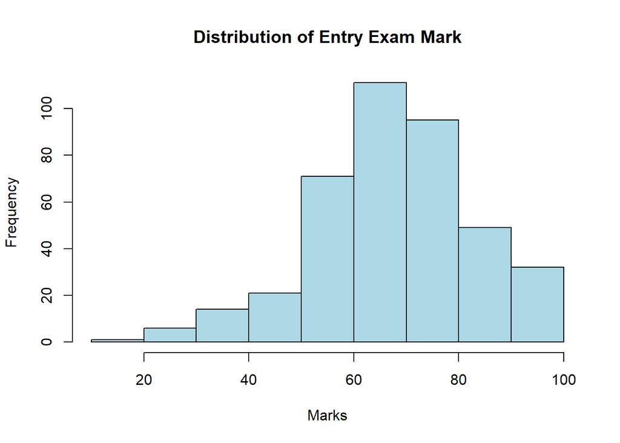

```r
# Histogram for 'entry_exam_mark'
hist(mydf_clean$entry_exam_mark, main = "Distribution of Entry Exam Mark",
     xlab = "Marks", col = "lightblue", border = "black", breaks = 10)
```

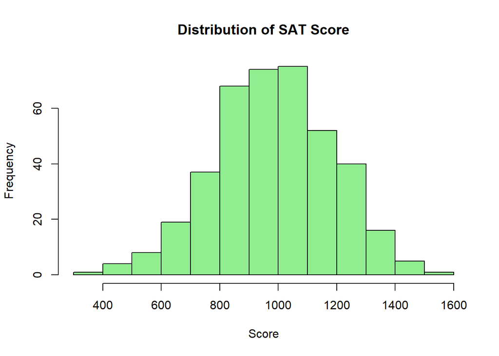

```r
# Histogram for 'sat_score'
hist(mydf_clean$sat_score, main = "Distribution of SAT Score",
     xlab = "Score", col = "lightgreen", border = "black", breaks = 10)
```

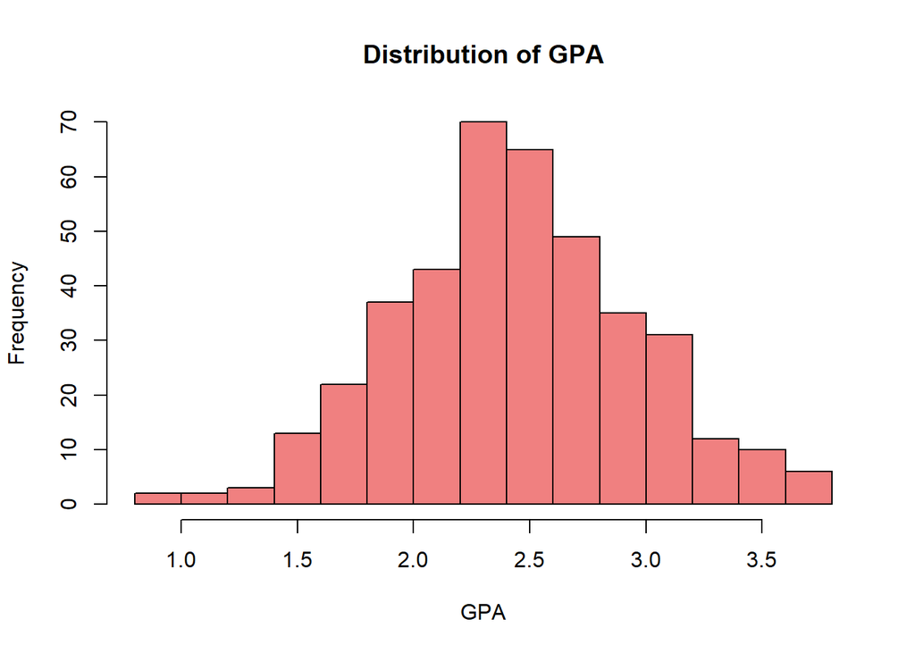

```r
# Histogram for 'grade_point_average'
hist(mydf_clean$grade_point_average, main = "Distribution of GPA",
     xlab = "GPA", col = "lightcoral", border = "black", breaks = 20)
```

## 2.2 Correlation between numerical variables

```r
selected_columns <- mydf_clean[, c("entry_exam_mark", "sat_score", "percentage_absence", "grade_point_average")]
correlation_matrix <- cor(selected_columns)
correlation_matrix
```

```
##                     entry_exam_mark sat_score percentage_absence
## entry_exam_mark           1.0000000 0.5917121         -0.3084477
## sat_score                 0.5917121 1.0000000          0.1791694
## percentage_absence       -0.3084477 0.1791694          1.0000000
## grade_point_average       0.6445324 0.7226863         -0.3644368
##                     grade_point_average
## entry_exam_mark               0.6445324
## sat_score                     0.7226863
## percentage_absence           -0.3644368
## grade_point_average           1.0000000
```

```r
str(mydf_clean)
```

```
## 'data.frame':    400 obs. of  9 variables:
##  $ student_id                : int  46 96 146 196 246 296 346 396 446 496 ...
##  $ entry_exam_mark           : num  59.8 55.6 63.5 85.7 74.7 ...
##  $ sat_score                 : num  686 888 1058 1469 1227 ...
##  $ percentage_absence        : num  10.51 5.69 17.31 14.77 0 ...
##  $ free_school_meals         : Factor w/ 2 levels "No","Yes": 2 2 1 1 1 1 2 1 1 2 ...
##  $ grade_point_average       : num  2.03 2.34 2.44 3.48 3.63 2.55 1.58 3.32 2.56 1.46 ...
##  $ completed.extended.project: Factor w/ 2 levels "No","Yes": 1 1 1 2 2 1 1 2 2 1 ...
##  $ month_of_birth            : Factor w/ 12 levels "April","August",..: 6 1 11 10 5 8 1 1 2 5 ...
##  $ commute_method            : Factor w/ 5 levels "Bicycle","Bus",..: 2 2 4 5 3 2 2 5 2 3 ...
```

## 2.3 Relationships

### 2.3.1 GPA x Completed Extended Project

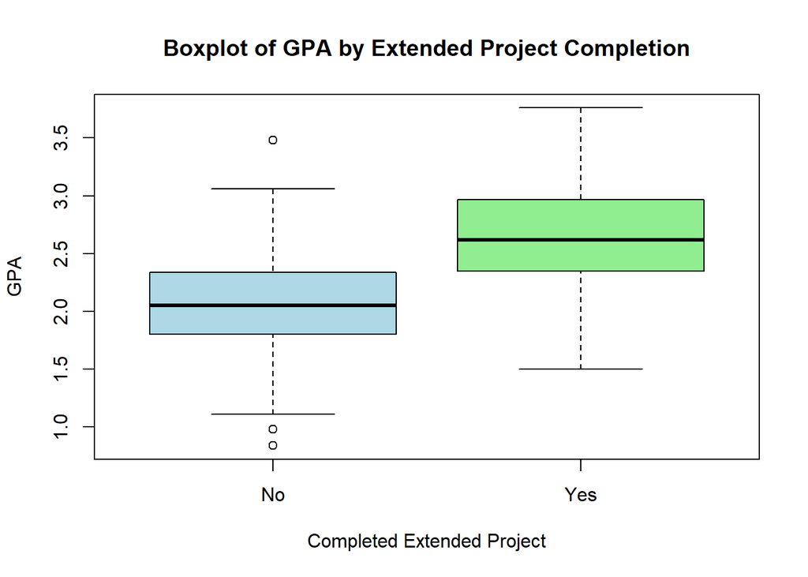

```r
# Create the boxplot
boxplot(grade_point_average ~ completed.extended.project,
        data = mydf_clean,
        main = "Boxplot of GPA by Extended Project Completion",
        xlab = "Completed Extended Project",
        ylab = "GPA",
        col = c("lightblue", "lightgreen"))
```

```r
t_test_result <- t.test(grade_point_average ~ completed.extended.project, data = mydf_clean)

t_test_result
```

```
##
##  Welch Two Sample t-test
##
## data:  grade_point_average by completed.extended.project
## t = -13.771, df = 310.36, p-value < 2.2e-16
## alternative hypothesis: true difference in means between group No and group Yes is not equal to 0
## 95 percent confidence interval:
##  -0.6837055 -0.5127528
## sample estimates:
##  mean in group No mean in group Yes
##          2.053972          2.652201
```

> Based on the t-test, we can reject the null hypothesis and confirm that there is a significant difference between the means of the ‘grade_point_average’ in the two groups. This implies that completing the extended project is associated with a measurable difference in GPA score.

### 2.3.2 GPA x SAT

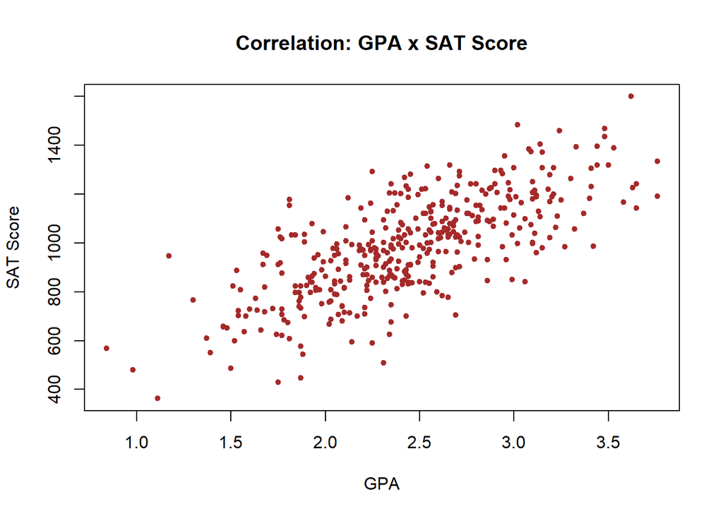

```r
# Ploting the scatter plot between the features
plot(mydf_clean$grade_point_average, mydf_clean$sat_score,
     main = "Correlation: GPA x SAT Score",
     xlab = "GPA",
     ylab = "SAT Score",
     pch = 20, col = "brown")
```

```r
cor.test(mydf$grade_point_average, mydf$sat_score)
```

```
##
##  Pearson's product-moment correlation
##
## data:  mydf$grade_point_average and mydf$sat_score
## t = 20.859, df = 398, p-value < 2.2e-16
## alternative hypothesis: true correlation is not equal to 0
## 95 percent confidence interval:
##  0.6722722 0.7664284
## sample estimates:
##       cor
## 0.7226863
```

> Based on the correlation test, we can reject the null hypothesis and confirm that there is a statistically significant correlation between grade_point_average and sat_score. This implies that the GPA performance is associated with SAT scores, suggesting a measurable relationship between these two variables.

### 2.3.3 Entry Exam Mark x GPA

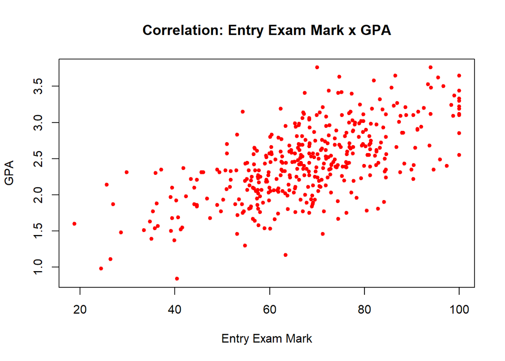

```r
# Ploting the scatter plot between the features
plot(mydf_clean$entry_exam_mark, mydf_clean$grade_point_average,
     main = "Correlation: Entry Exam Mark x GPA",
     xlab = "Entry Exam Mark",
     ylab = "GPA",
     pch = 20, col = "red")
```

```r
cor.test(mydf$entry_exam_mark, mydf$grade_point_average)
```

```
##
##  Pearson's product-moment correlation
##
## data:  mydf$entry_exam_mark and mydf$grade_point_average
## t = 10.337, df = 398, p-value < 2.2e-16
## alternative hypothesis: true correlation is not equal to 0
## 95 percent confidence interval:
##  0.3790983 0.5340126
## sample estimates:
##       cor
## 0.4600494
```

> Based on the correlation test, we can reject the null hypothesis and confirm that there is a statistically significant correlation between entry_exam_mark and grade_point_average. This implies that entry exam performance is associated with GPA scores.